# 6. Predstavljanje podataka u tablicama

U ovoj lekciji ćemo govoriti o:

1. kako predstaviti tablice pomoću lista u Pythonu;
2. kako predstaviti tablice pomoću učinkovitijeg modela koji pruža biblioteka *pandas* ;
3. kako vizualizirati podatke predstavljene kao tablice; i
4. kako čitati tablice iz lokalnih datoteka i udaljenih izvora.

## 6.1. Predstavljanje tablica zadanih podataka pomoću lista

Najefikasniji način organiziranja velikih količina podataka je da se oni stave u tablicu. Na primjer, ova tablica sadrži neke osnovne činjenice o grupi učenika:

| **Ime** | **Spol** | **God (yrs)** | **Težina (kg)** | **Visina (cm)** |
| --- | --- | --- | --- | --- |
| Anne | f | 13 | 46 | 160 |
| Ben | m | 14 | 52 | 165 |
| Colin | m | 13 | 47 | 157 |
| Diana | f | 15 | 54 | 165 |
| Ethan | m | 15 | 56 | 163 |
| Fred | m | 13 | 45 | 159 |
| Gloria | f | 14 | 49 | 161 |
| Hellen | f | 15 | 52 | 164 |
| Ian | m | 15 | 57 | 167 |
| Jane | f | 13 | 45 | 158 |
| Kate | f | 14 | 51 | 162 |

Da bismo mogli da obrađujemo i analiziramo podatke, prvo smo trebali predstaviti u obliku strukture podatka. Jedan jednostavan način je da učinite da svaki crveni red tablice predstavimo jednom listu, i da sve te liste zapakiramo u jednu veliku listu, recimo ovako:

```python
podaci = [["Anne",    "f", 13, 46, 160],
            ["Ben",     "m", 14, 52, 165],
            ["Colin",   "m", 13, 47, 157],
            ["Diana",   "f", 15, 54, 165],
            ["Ethan",   "m", 15, 56, 163],
            ["Fred",    "m", 13, 45, 159],
            ["Gloria",  "f", 14, 49, 161],
            ["Hellen",  "f", 15, 52, 164],
            ["Ian",     "m", 15, 57, 167],
            ["Jane",    "f", 13, 45, 158],
            ["Kate",    "f", 14, 51, 162]]
```

Sada lako možemo dohvatiti podatke o bilo kojem učeniku u grupi. Na primjer, da bismo vidjeli podatke o Ethanu jednostavno upišemo `podaci[4]` (*Važno! Prvi element liste ima indeks 0, zato podaci o Ethanu koji su navedeni u 5. redu tablice imaju indeks 4*):

```python
podaci[4]
```

```
['Ethan', 'm', 15, 56, 163]
```

S druge strane, takav je način prikazivanja tablica nezgodan jer nije lako raditi sa stupcima tablice. Na primjer, ako želimo izračunati prosječnu visinu učenika u grupi, morali bismo napisati program:

```python
sum = 0
for dijete in podaci:
    sum += dijete[4]
float(sum) / len(podaci)
```

```
161.9090909090909
```

Program radi na sljedeći način:

- prvo inicijaliziramo varijablu `sum` na 0 (na kraju će sadržavati zbroj visina učenika);
- nakon tog ciklusa `for dijete in podaci`: prolazi svako dijete u grupi (jer svaki element liste `podaci` predstavlja podatke o jednom djetetu) i dodaje zbroju njegove visine (visina djeteta je na petom mjestu u grupi podataka za to dijete, a to je element liste s indeksom 4);
- konačno izračunavamo prosjek.

Ovo nije teško, ali isto tako nije baš povoljno. Potrebna nam je fleksibilnija struktura podataka.

## 6.2. Biblioteka *pandas*, struktura podataka *DataFrame* i rad sa stupcima tablice

Biblioteka *pandas* razvijena je s efektivnim načinom izrade tablica. Uvozimo biblioteku i dodijeli joj nadimak:

```python
import pandas as pd
```

Ova biblioteka pruža snažnu strukturu podataka nazvanu *DataFrame*. Započnimo pretvaranjem podataka o grupi učenika u DataFrame:

```python
studenti_df = pd.DataFrame(studenti)
```

```python
studenti_df
```

|  | 0 | 1 | 2 | 3 | 4 |
| --- | --- | --- | --- | --- | --- |
| 0 | Anne | f | 13 | 46 | 160 |
| 1 | Ben | m | 14 | 52 | 165 |
| 2 | Colin | m | 13 | 47 | 157 |
| 3 | Diana | f | 15 | 54 | 165 |
| 4 | Ethan | m | 15 | 56 | 163 |
| 5 | Fred | m | 13 | 45 | 159 |
| 6 | Gloria | f | 14 | 49 | 161 |
| 7 | Hellen | f | 15 | 52 | 164 |
| 8 | Ian | m | 15 | 57 | 167 |
| 9 | Jane | f | 13 | 45 | 158 |
| 10 | Kate | f | 14 | 51 | 162 |

Sve informacije su tu, poredane u urednu tablicu. Da bismo tablicu učinili čitljivijom, imenovat ćemo stupce tablice pomoću opcije `columns`:

```python
studenti_df.columns=["Ime", "Spol", "Godine", "Težina", "Visina"]
studenti_df
```

|  | Ime | Spol | Godine | Težina | Visina |
| --- | --- | --- | --- | --- | --- |
| 0 | Anne | f | 13 | 46 | 160 |
| 1 | Ben | m | 14 | 52 | 165 |
| 2 | Colin | m | 13 | 47 | 157 |
| 3 | Diana | f | 15 | 54 | 165 |
| 4 | Ethan | m | 15 | 56 | 163 |
| 5 | Fred | m | 13 | 45 | 159 |
| 6 | Gloria | f | 14 | 49 | 161 |
| 7 | Hellen | f | 15 | 52 | 164 |
| 8 | Ian | m | 15 | 57 | 167 |
| 9 | Jane | f | 13 | 45 | 158 |
| 10 | Kate | f | 14 | 51 | 162 |

Sada, kada svaki stupac ima svoje ime, možemo pristupiti pojedinačnim kolonama ovako:

```python
studenti_df["Ime"]
```

```
0       Anne
1        Ben
2      Colin
3      Diana
4      Ethan
5       Fred
6     Gloria
7     Hellen
8        Ian
9       Jane
10      Kate
Name: Ime, dtype: object
```

```python
studenti_df["Visina"]
```

```
0     160
1     165
2     157
3     165
4     163
5     159
6     161
7     164
8     167
9     158
10    162
Name: Visina, dtype: int64
```

U tablici možete uvijek dobiti naziv svih stupaca:

```python
studenti_df.columns
```

```
Index(['Ime', 'Spol', 'Godine', 'Težina', 'Visina'], dtype='object')
```

Sljedeće funkcije olakšavaju nam izračunavanje elementarnih statistika na stupcima DataFramea:

- `sum` -- zbroj elemenata u stupcu;
- `mean` -- prosječna vrijednost (*aritmetička sredina*) elemenata u stupcu;
- `median` -- srednja vrijednost elemenata u stupcu;
- `min` -- minimalna vrijednost elemenata u stupcu;
- `max` -- maksimalna vrijednost elemenata u stupcu.

Na primjer, visina najkraćeg učenika je:

```python
studenti_df["Visina"].min()
```

```
157
```

Godine najstarijeg učenika:

```python
studenti_df["Godine"].max()
```

```
15
```

Prosječna visina učenika:

```python
studenti_df["Visina"].mean()
```

```
161.9090909090909
```

Srednja visina:

```python
studenti_df["Visina"].median()
```

```
162.0
```

Može li se cijela skupina uklopiti u lift koji ima najviše 600 kg?

```python
if studenti_df["Težina"].sum() <= 600:
    print("Mogu svi stati u lift.")
else:
    print("Ne. Zajedno su preteški.")
```

```
Mogu svi stati u lift.
```

## 6.3. Vizualizacija podataka predstavljenih DataFrame-om

To je jednostavno: samo odaberite stupce koje želite vizualizirati. Da vidimo nekoliko primjera započinjemo učitavanjem odgovarajuće biblioteke:

```python
import matplotlib.pyplot as plt
```

Da bismo vizualizirali visinu učenika u grupi, jednostavno crtamo grafikon koji prikazuje imena i visine učenika:

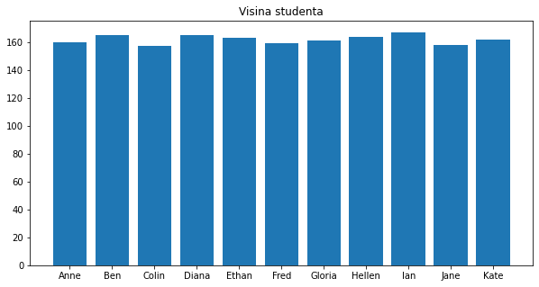

```python
plt.figure(figsize=(10,5))
plt.bar(studenti_df["Ime"], studenti_df["Visina"])
plt.title("Visina studenta")
plt.show()
plt.close()
```

Također možemo vizualizirati godine i težinu učenika:

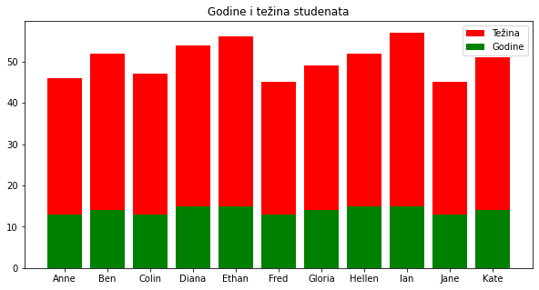

```python
plt.figure(figsize=(10,5))
plt.bar(studenti_df["Ime"], studenti_df["Težina"], color="r", label="Težina")
plt.bar(studenti_df["Ime"], studenti_df["Godine"], color="g", label="Godine")
plt.title("Godine i težina studenata")
plt.legend()
plt.show()
plt.close()
```

## 6.4. Učitavanje podataka iz lokalnih *CSV* datoteka

Analiza podataka koja najviše troši i najmanje privlači posao je pretvaranje neobrađenih podataka u tablice. Možda niste primijetili da su tablice koje koristimo za demonstraciju bile male, ali u stvarnim životnim situacijama obično dobivamo ogromne tablice s tisućama redaka i stupaca. (Jeste li ikada čuli za dio znanosti o podacima koji se zove Big Data?)

Danas koristimo strojeve za prikupljanje podataka (automatske meteorološke stanice, računalna biračka mjesta itd.). Strojevi zatim spakiraju prikupljene podatke u neki vrlo jednostavan format koji kasnije možemo učitati i obraditi. *CSV* označava "comma separated values = vrijednost odvojena zarezima" i jedan je od najjednostavnijih (i najpopularnijih) formata za predstavljanje tablica. CSV datoteke su tekstualne datoteke čiji redovi odgovaraju redovima tablice, a vrijednosti unutar istog retka odvojene su zarezima ("comma separated values").

Na primjer, postoji datoteka Top 25 YouTubers.csv u podacima mape koja izgleda ovako:

```
RANK,GRADE,NAME,VIDEOS,SUBSCRIBERS,VIEWES
1,A++,T-Series,13629,105783888,76945588449
2,A,PewDiePie,3898,97853589,22298927681
3,A+,5-Minute Crafts,3341,58629572,14860695079
4,A++,Cocomelon - Nursery Rhymes,441,53163816,33519273951
...
25,A,TheEllenShow,10542,33362512,16519572219
```

Ova tablica sadrži podatke o 25 najboljih YouTube kanala prema broju pretplatnika 1. srpnja 2019. Prvi red datoteke je redak zaglavlja koji nam govori da tablica ima šest stupaca (RANK, GRADE, NAME, VIDEOS, SUBSCRIBERS , Viewes). Red

```
4,A++,Cocomelon - Nursery Rhymes,441,53163816,33519273951
```

znači da 4. najpopularniji YouTube kanal (1. srpnja 2019.) ima YouTube rang A ++, njegovo ime je "Cocomelon - Nursery Rhymes", objavio je 441 videozapis na YouTubeu, ima 53.163.816 pretplatnika i 33.519.273.951 pregleda.

Funkcija `read_csv` iz `pandas` čita *CSV* datoteku i pretvara je u *DataFrame*. Na primjer:

```python
import pandas as pd
Top25 = pd.read_csv("data/Top 25 YouTubers.csv")
```

U tablicu možemo zaviriti pomoću funkcije `head(N)` koja prikazuje prvih N redaka tablice. Ako bez argumenata pozivamo funkciju, ona prikazuje prvih pet redaka:

```python
Top25.head()
```

|  | RANK | GRADE | NAME | VIDEOS | SUBSCRIBERS | VIEWES |
| --- | --- | --- | --- | --- | --- | --- |
| 0 | 1 | A++ | T-Series | 13629 | 105783888 | 76945588449 |
| 1 | 2 | A | PewDiePie | 3898 | 97853589 | 22298927681 |
| 2 | 3 | A+ | 5-Minute Crafts | 3341 | 58629572 | 14860695079 |
| 3 | 4 | A++ | Cocomelon - Nursery Rhymes | 441 | 53163816 | 33519273951 |
| 4 | 5 | A++ | SET India | 31923 | 51784081 | 36464793233 |

```python
Top25.head(10)
```

|  | RANK | GRADE | NAME | VIDEOS | SUBSCRIBERS | VIEWES |
| --- | --- | --- | --- | --- | --- | --- |
| 0 | 1 | A++ | T-Series | 13629 | 105783888 | 76945588449 |
| 1 | 2 | A | PewDiePie | 3898 | 97853589 | 22298927681 |
| 2 | 3 | A+ | 5-Minute Crafts | 3341 | 58629572 | 14860695079 |
| 3 | 4 | A++ | Cocomelon - Nursery Rhymes | 441 | 53163816 | 33519273951 |
| 4 | 5 | A++ | SET India | 31923 | 51784081 | 36464793233 |
| 5 | 6 | A+ | Canal KondZilla | 1100 | 50560964 | 25446405744 |
| 6 | 7 | A+ | WWE | 42404 | 46098586 | 34085586984 |
| 7 | 8 | B+ | Justin Bieber | 134 | 45873439 | 625649566 |
| 8 | 9 | A | Dude Perfect | 209 | 43796634 | 8354321862 |
| 9 | 10 | A+ | Badabun | 4406 | 41131131 | 13175713909 |

Funkcija `tail(N)` prikazuje zadnjih N redaka tablice (ili samo 5 ako nije naveden arguement):

```python
Top25.tail()
```

|  | RANK | GRADE | NAME | VIDEOS | SUBSCRIBERS | VIEWES |
| --- | --- | --- | --- | --- | --- | --- |
| 20 | 21 | B- | Katy Perry | 97 | 34416819 | 361332307 |
| 21 | 22 | A | Felipe Neto | 1872 | 33549096 | 7458531306 |
| 22 | 23 | A | JustinBieberVEVO | 122 | 33514535 | 18873475304 |
| 23 | 24 | A | Fernanfloo | 534 | 33378699 | 7201866552 |
| 24 | 25 | A | TheEllenShow | 10542 | 33362512 | 16519572219 |

```python
Top25.tail(7)
```

|  | RANK | GRADE | NAME | VIDEOS | SUBSCRIBERS | VIEWES |
| --- | --- | --- | --- | --- | --- | --- |
| 18 | 19 | A- | elrubiusOMG | 809 | 35324033 | 7772447040 |
| 19 | 20 | B | Taylor Swift | 166 | 34920060 | 255089844 |
| 20 | 21 | B- | Katy Perry | 97 | 34416819 | 361332307 |
| 21 | 22 | A | Felipe Neto | 1872 | 33549096 | 7458531306 |
| 22 | 23 | A | JustinBieberVEVO | 122 | 33514535 | 18873475304 |
| 23 | 24 | A | Fernanfloo | 534 | 33378699 | 7201866552 |
| 24 | 25 | A | TheEllenShow | 10542 | 33362512 | 16519572219 |

Zamislimo broj pretplatnika najboljih 25 YouTube kanala:

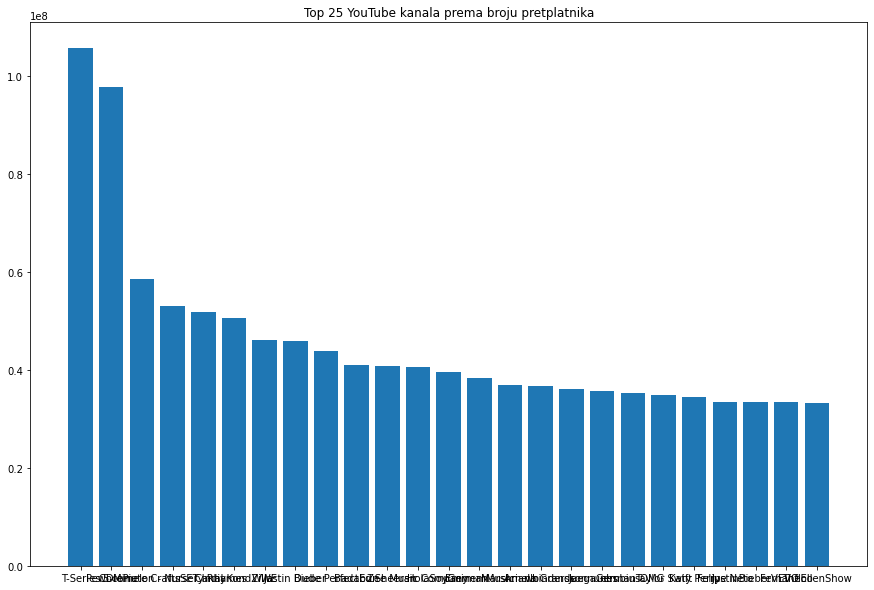

```python
plt.figure(figsize=(15,10))
plt.bar(Top25["NAME"], Top25["SUBSCRIBERS"])
plt.title("Top 25 YouTube kanala prema broju pretplatnika")
plt.show()
plt.close()
```

Nered je zbog toga što su imena kanala predugačka. U tim situacijama uporaba `barh` umjesto `bar` može dati bolje rezultate:

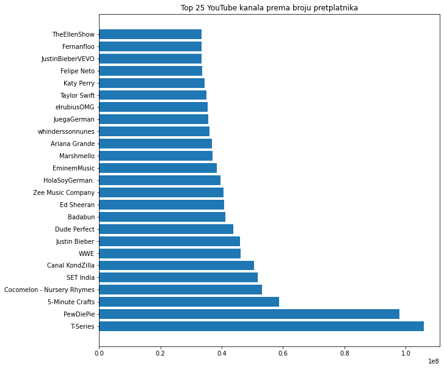

```python
plt.figure(figsize=(10,10))
plt.barh(Top25["NAME"], Top25["SUBSCRIBERS"])
plt.title("Top 25 YouTube kanala prema broju pretplatnika")
plt.show()
plt.close()
```

## 6.5. Učitavanje podataka iz udaljenih izvora

Također možete izravno učitati podatke s udaljenog izvora, bez potrebe za preuzimanjem podataka na uređaj. Da biste mogli učitati tablicu s udaljenog resursa, potrebna vam je internetska veza (naravno!) I morate znati točno mjesto tablice koju želite učitati. Točna lokacija Internet resouces-a pružena je u njegovom *URL-u* (što označava *Universal Resource Locator* ).

"Internet adresa"

```
https://raw.githubusercontent.com/cs109/2014_data/master/countries.csv
```

sadrži javno dostupan popis svih zemalja svijeta. Ovu tablicu možemo čitati izravno koristeći `read_csv`:

```python
countries = pd.read_csv("https://raw.githubusercontent.com/cs109/2014_data/master/countries.csv")
countries.head(10)
```

|  | Country | Region |
| --- | --- | --- |
| 0 | Algeria | AFRICA |
| 1 | Angola | AFRICA |
| 2 | Benin | AFRICA |
| 3 | Botswana | AFRICA |
| 4 | Burkina | AFRICA |
| 5 | Burundi | AFRICA |
| 6 | Cameroon | AFRICA |
| 7 | Cape Verde | AFRICA |
| 8 | Central African Republic | AFRICA |
| 9 | Chad | AFRICA |

Tablice dostupne na Internetu obično nisu prikladno pakirane u CSV datoteku. Najčešće su ugrađeni u web stranicu i okruženi nekim dodatnim *HTML* kodom (*HTML* znači "hyper-text markup language" i označava jezik na kojem su kodirane sve web stranice na Zemlji).

Srećom, funkcija `read_html` može zauzeti web stranicu i iz nje izvući tablicu. Na primjer, sljedeći kod čita popis svih američkih država u DataFrame izravno s web stranice Wikipedije:

```python
US = pd.read_html("https://simple.wikipedia.org/wiki/List_of_U.S._states", header=[0,1])[0]
```

Web stranice su složene i mogu sadržavati nekoliko tablica. Zbog toga `read_html` vraća listu tablica. U ovom slučaju tablica koja nam je potrebna prva je na listi, otuda i indeksiranje `[0]`. Opcija `header=[0,1]` znači da prva dva reda tablice čine zaglavlje. Pogledajmo:

```python
US.head()
```

|  | Name &postal abbreviation[1] | Name &postal abbreviation[1] Name &postal abbreviation[1].1 | Cities Capital | Cities Largest[5] | Established[upper-alpha 1] | Population[upper-alpha 2][3] | Total area[4] mi2 | Total area[4] km2 | Land area[4] mi2 | Land area[4] km2 | Water area[4] mi2 | Water area[4] km2 | Numberof Reps. |
| --- | --- | --- | --- | --- | --- | --- | --- | --- | --- | --- | --- | --- | --- |
| 0 | Alabama | AL | Montgomery | Birmingham | Dec 14, 1819 | 4903185 | 52420 | 135767 | 50645 | 131171 | 1775 | 4597 | 7 |
| 1 | Alaska | AK | Juneau | Anchorage | Jan 3, 1959 | 731545 | 665384 | 1723337 | 570641 | 1477953 | 94743 | 245384 | 1 |
| 2 | Arizona | AZ | Phoenix | Phoenix | Feb 14, 1912 | 7278717 | 113990 | 295234 | 113594 | 294207 | 396 | 1026 | 9 |
| 3 | Arkansas | AR | Little Rock | Little Rock | Jun 15, 1836 | 3017804 | 53179 | 137732 | 52035 | 134771 | 1143 | 2961 | 4 |
| 4 | California | CA | Sacramento | Los Angeles | Sep 9, 1850 | 39512223 | 163695 | 423967 | 155779 | 403466 | 7916 | 20501 | 53 |

## 6.6. Zadaci

Zadatke riješite u Jupyteru.

**Zadatak 1.** Pogledajte kod i odgovorite na donja pitanja:

```
157 161.5 161.5
```

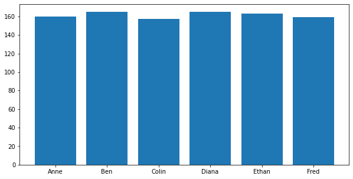

```python
import pandas as pd
import matplotlib.pyplot as plt

studenti = [["Anne",    "f", 13, 46, 160],
            ["Ben",     "m", 14, 52, 165],
            ["Colin",   "m", 13, 47, 157],
            ["Diana",   "f", 15, 54, 165],
            ["Ethan",   "m", 15, 56, 163],
            ["Fred",    "m", 13, 45, 159]]

table = pd.DataFrame(studenti)
table.columns=["Ime", "Spol", "Godine", "Težina", "Visina"]

print(table["Visina"].min(), table["Visina"].mean(), table["Visina"].median())

plt.figure(figsize=(10,5))
plt.bar(table["Ime"], table["Visina"])
plt.show()
plt.close()

temp_anomalije = pd.read_csv("data/TempAnomalies.csv", header=None)
drzave = pd.read_csv("https://raw.githubusercontent.com/cs109/2014_data/master/countries.csv")
US = pd.read_html("https://simple.wikipedia.org/wiki/List_of_U.S._states", header=[0,1])[0]
```

1. Zašto moramo uvesti dvije biblioteke?
2. Zašto tablice predstavljamo DataFrame-ovima, a ne liste?
3. Kako se nazivaju stupci u tablici DataFrame `table`?
4. Koja je razlika između `min`, `mean` i `median`?
5. Što morate promijeniti da grafikon prikaže težinu učenika?
6. Kako biste učitali datoteku `TempAnomalies.csv` ako bi imala redak zaglavlja?
7. Jesu li države DataFrame `countries` stvorene iz podataka pohranjenih lokalno na vašem računalu?
8. Koji je format tablice iz koje je kreiran DataFrame `US`?
9. Što se događa ako u preglednik upišete `https://simple.wikipedia.org/wiki/List_of_U.S._states`?

**Zadatak 2.** Donja tablica prikazuje proizvodnju kukuruza, pšenice u poljoprivrednoj regiji Europe (brojke su u 1000 tona):

| Godina | Kukuruz | Pšenica |
| --- | --- | --- |
| 2008 | 6,158 | 2,095 |
| 2009 | 6,396 | 2,067 |
| 2010 | 7,207 | 1,631 |
| 2011 | 6,480 | 2,076 |
| 2012 | 3,532 | 1,911 |

*(a)* Pretvorite ovu tablicu na listu i iz liste stvorite DataFrame. Zatim izračunajte maksimalni prinos kukuruza i minimalni prinos pšenice.

*(b)* Vizualizirajte podatke pomoću grafikona.

*(c)* izračunati prosječni prinos kukuruza; zatim izračunajte razliku između maksimalnog i minimalnog prinosa pšenice.

**Zadatak 3.** Ovo je pregled potrošnje obitelji tijekom jedne godine (u lokalnoj valuti):

| Stavka | Jan | Feb | Mar | Apr | May | Jun | Jul | Aug | Sep | Oct | Nov | Dec |
| --- | --- | --- | --- | --- | --- | --- | --- | --- | --- | --- | --- | --- |
| Stanarina | 8,251 | 8,436 | 8,524 | 8,388 | 8,241 | 8,196 | 8,004 | 7,996 | 7,991 | 8,015 | 8,353 | 8,456 |
| Struja | 4,321 | 4,530 | 4,115 | 3,990 | 3,985 | 3,726 | 3,351 | 3,289 | 3,295 | 3,485 | 3,826 | 3,834 |
| Telefon (fiksni) | 1,425 | 1,538 | 1,623 | 1,489 | 1,521 | 1,485 | 1,491 | 1,399 | 1,467 | 1,531 | 1,410 | 1,385 |
| Telefon (mobitel) | 2,181 | 2,235 | 2,073 | 1,951 | 1,989 | 1,945 | 3,017 | 2,638 | 2,171 | 1,831 | 1,926 | 1,833 |
| TV i Internet | 2,399 | 2,399 | 2,399 | 2,399 | 2,399 | 2,399 | 2,399 | 2,399 | 2,399 | 2,399 | 2,399 | 2,399 |
| Prijevoz | 1,830 | 1,830 | 1,830 | 1,830 | 1,950 | 1,950 | 1,450 | 1,450 | 1,950 | 1,950 | 2,050 | 2,050 |
| Hrana | 23,250 | 23,780 | 24,019 | 24,117 | 24,389 | 24,571 | 24,736 | 24,951 | 25,111 | 25,389 | 25,531 | 25,923 |
| Ostalo | 4,500 | 3,700 | 5,100 | 3,500 | 2,750 | 4,250 | 7,320 | 8,250 | 3,270 | 4,290 | 3,200 | 8,390 |

Ova tablica je predstavljena kao lista i izgleda ovako:

```python
troskovi = [
  ["Stanarina", 8251, 8436, 8524, 8388, 8241, 8196, 8004, 7996, 7991, 8015, 8353, 8456],
  ["Struja", 4321, 4530, 4115, 3990, 3985, 3726, 3351, 3289, 3295, 3485, 3826, 3834],
  ["Telefon (fiksni)", 1425, 1538, 1623, 1489, 1521, 1485, 1491, 1399, 1467, 1531, 1410, 1385],
  ["Telefon (mobitel)", 2181, 2235, 2073, 1951, 1989, 1945, 3017, 2638, 2171, 1831, 1926, 1833],
  ["TV i Internet", 2399, 2399, 2399, 2399, 2399, 2399, 2399, 2399, 2399, 2399, 2399, 2399 ],
  ["Prijevoz", 1830, 1830, 1830, 1830, 1950, 1950, 1450, 1450, 1950, 1950, 2050, 2050],
  ["Hrana", 23250, 23780, 24019, 24117, 24389, 24571, 24736, 24951, 25111, 25389, 25531, 25923],
  ["Ostalo", 4500, 3700, 5100, 3500, 2750, 4250, 7320, 8250, 3270, 4290, 3200, 8390]
]
```

*(a)* Pretvorite ovo u *DataFrame*.

*(b)* Izračunajte ukupnu potrošnju mjesečno (koliko u January, koliko u February, itd).

**Zadatak 4.** Podaci datoteke *data/LEB.csv* sadrže ukupnu *Life Expectancy at Birth* ljudi izračunatu u petogodišnjem razdoblju.

*(a)* Učitajte ovu datoteku u *DataFrame*.

*(b)* Vizualizirajte podatke.

**Zadatak 5.** Na satu tjelesnog studenti su uvježbavali skokove u dalj. Svaki je student imao tri pokušaja, a podaci se prikupljaju u *LongJump.csv* dostupno u podacima u mapi. Prvi red datoteke je zaglavlje.

*(a)* Učitajte ovu datoteku u *DataFrame*.

*(b)* Vizualizirajte podatke pomoću grafikona. (Savjet: Budite kreativni.)

**Zadatak 6.** Na sljedećem URL-u

```
https://raw.githubusercontent.com/resbaz/r-novice-gapminder-files/master/data/gapminder-FiveYearData.csv
```

možete pronaći javno dostupnu tablicu s popisom zemalja svijeta i nekim parametrima gospodarskog razvoja država sažeto u intervalima od pet godina. Tablica ima sljedeće stupce:

- zemlja
- godina
- pop (= populacija)
- kontinent
- lifeExp (= životni vijek; koliko godina u prosjeku ima državljanin te zemlje za živjeti)
- gdpPercap (= BDP po glavi stanovnika; koliko novca, u prosjeku američki dolari, zarađuju građani te zemlje)

Učitajte ovu tablicu u *DataFrame* i prikažite prvih 20 redaka kao i zadnjih 10 redaka tablice.

**Zadatak 7.** Učitajte tablicu sa sljedećeg URL-a

```
https://www.worldometers.info/world-population/population-by-country/
```

u DataFrame i prikažite prvih nekoliko redaka tablice.

© 2019 [Petlja.org](https://petlja.org)